# NYPD Shooting Incidents

Sean Coffey

2024-07-08

## Import NYPD Shooting Incident Data Set

List of every shooting incident that occurred in NYC going back to 2006 through the end of the previous calendar year.

This is a breakdown of every shooting incident that occurred in NYC going back to 2006 through the end of the previous calendar year. This data is manually extracted every quarter and reviewed by the Office of Management Analysis and Planning before being posted on the NYPD website. Each record represents a shooting incident in NYC and includes information about the event, the location and time of occurrence. In addition, information related to suspect and victim demographics is also included. This data can be used by the public to explore the nature of shooting/criminal activity.

```r
# creates a variable containing the csv file downloaded from the data.gov website
nypd_url = "https://data.cityofnewyork.us/api/views/833y-fsy8/rows.csv?accessType=DOWNLOAD"
nypd_data = read_csv(nypd_url)

pop_url = "https://data.cityofnewyork.us/api/views/xywu-7bv9/rows.csv?accessType=DOWNLOAD"
pop_data = read_csv(pop_url)
```

## Basic tidying and transforming of the data set

The data is already tidy (one row per incident). There are two main issues with the data to resolve:

1. Data types: much of the data are really factors but recorded as character
2. Many missing values, which may be something I will have to re-visit, once I’ve done some analysis.

The missing values issue with the perp data (age-group, sex, race) is significant, approx half the observations are unknown or NA. There is no sensible imputation here, so will probably have to accept that analysis of these factors may be misleading and needs to be handled carefully.

```r
# Add fips codes to data, which can be used later for simple geo visualisation
fips_codes <- as_tibble(matrix(c("BRONX","BROOKLYN","MANHATTAN","QUEENS","STATEN ISLAND",36005,36047,36061,36081,36085),ncol = 2))
```

```r
colnames(fips_codes) <-c("BORO","fips")
fips_codes$fips = as.integer(fips_codes$fips)

nypd <-nypd_data %>%
  # changing the data types appropriately
  mutate(OCCUR_DATE = mdy(OCCUR_DATE),
         BORO = factor(BORO),
         LOC_OF_OCCUR_DESC = factor(LOC_OF_OCCUR_DESC),
         JURISDICTION_CODE = factor(JURISDICTION_CODE, labels = c("Patrol", "Transit", "Housing")),
         LOC_CLASSFCTN_DESC = factor(LOC_CLASSFCTN_DESC),
         PERP_AGE_GROUP = factor(PERP_AGE_GROUP),
         PERP_SEX = factor(PERP_SEX),
         PERP_RACE = factor(PERP_RACE),
         VIC_AGE_GROUP = factor(VIC_AGE_GROUP),
         VIC_SEX = factor(VIC_SEX),
         VIC_RACE = factor(VIC_RACE),
         Longitude = as.numeric(Longitude),
         Latitude = as.numeric(Latitude)) %>%
  #Partial field selection for project analyses - reducing from 21 columns to 15
  #Location information has a high percentage of missing values, so will remove for now
  full_join(fips_codes) %>%
  select(OCCUR_DATE, OCCUR_TIME, fips, BORO, PRECINCT, JURISDICTION_CODE, LOCATION_DESC,
         STATISTICAL_MURDER_FLAG, PERP_AGE_GROUP, PERP_SEX, PERP_RACE, VIC_AGE_GROUP, VIC_SEX, VIC_RACE,
         Latitude, Longitude) # keeping because if I have time, may look at trying to plot on map.
# Simple population data transformed to support use in geo analysis below
pop <- pop_data %>%
  select(Borough,"1950","1960","1970","1980","1990","2000","2010","2020") %>%
  pivot_longer(
    cols = c("1950","1960","1970","1980","1990","2000","2010","2020"),
    names_to = "year",
    values_to = "population"
    ) %>%
  rename(BORO = Borough) %>%
  mutate(BORO = toupper(BORO),
         year = as.integer(year)) %>%
  filter(BORO != "NYC TOTAL") %>%
  full_join(fips_codes, by = join_by(BORO == BORO))

summary(nypd)
```

```
##    OCCUR_DATE          OCCUR_TIME            fips           BORO
##  Min.   :2006-01-01   Length:28562      Min.   :36005   Length:28562
##  1st Qu.:2009-09-04   Class1:hms        1st Qu.:36005   Class :character
##  Median :2013-09-20   Class2:difftime   Median :36047   Mode  :character
##  Mean   :2014-06-07   Mode  :numeric    Mean   :36043
##  3rd Qu.:2019-09-29                     3rd Qu.:36061
##  Max.   :2023-12-29                     Max.   :36085
##
##     PRECINCT     JURISDICTION_CODE LOCATION_DESC      STATISTICAL_MURDER_FLAG
##  Min.   :  1.0   Patrol :23923     Length:28562       Mode :logical
##  1st Qu.: 44.0   Transit:   81     Class :character   FALSE:23036
##  Median : 67.0   Housing: 4556     Mode  :character   TRUE :5526
##  Mean   : 65.5   NA's   :    2
##  3rd Qu.: 81.0
##  Max.   :123.0
##
##  PERP_AGE_GROUP   PERP_SEX              PERP_RACE     VIC_AGE_GROUP   VIC_SEX
##  18-24  :6438   (null): 1141   BLACK         :11903   <18    : 2954   F: 2760
##  25-44  :6041   F     :  444   WHITE HISPANIC: 2510   1022   :    1   M:25790
##  UNKNOWN:3148   M     :16168   UNKNOWN       : 1837   18-24  :10384   U:   12
##  <18    :1682   U     : 1499   BLACK HISPANIC: 1392   25-44  :12973
##  (null) :1141   NA's  : 9310   (null)        : 1141   45-64  : 1981
##  (Other): 768                  (Other)       :  469   65+    :  205
##  NA's   :9344                  NA's          : 9310   UNKNOWN:   64
##                            VIC_RACE        Latitude       Longitude
##  AMERICAN INDIAN/ALASKAN NATIVE:   11   Min.   :40.51   Min.   :-74.25
##  ASIAN / PACIFIC ISLANDER      :  440   1st Qu.:40.67   1st Qu.:-73.94
##  BLACK                         :20235   Median :40.70   Median :-73.92
##  BLACK HISPANIC                : 2795   Mean   :40.74   Mean   :-73.91
##  UNKNOWN                       :   70   3rd Qu.:40.82   3rd Qu.:-73.88
##  WHITE                         :  728   Max.   :40.91   Max.   :-73.70
##  WHITE HISPANIC                : 4283   NA's   :59      NA's   :59
```

```r
summary(pop)
```

```
##      BORO                year        population           fips
##  Length:40          Min.   :1950   Min.   : 191555   Min.   :36005
##  Class :character   1st Qu.:1968   1st Qu.:1300435   1st Qu.:36047
##  Mode  :character   Median :1985   Median :1545041   Median :36061
##                     Mean   :1985   Mean   :1569122   Mean   :36056
##                     3rd Qu.:2002   3rd Qu.:2229768   3rd Qu.:36081
##                     Max.   :2020   Max.   :2738175   Max.   :36085
```

## First visualisations

I’m using this project as an opportunity to revise my R basics rather than to create a meaningful analysis of the NYPD data. Accordingly, I will not spend time textualising conclusions.

However a couple of simple observations, without quantification: 1. COVID seemed to have an impact (being careful not to assume causation from correlation), the number of shootings rose from 2020. 2. Majority happen at night 3. More likely to happen in summer than winter 4. Victims are more likely to be men than women and younger rather than older. 5. Overall there is trend downwards (see model section)

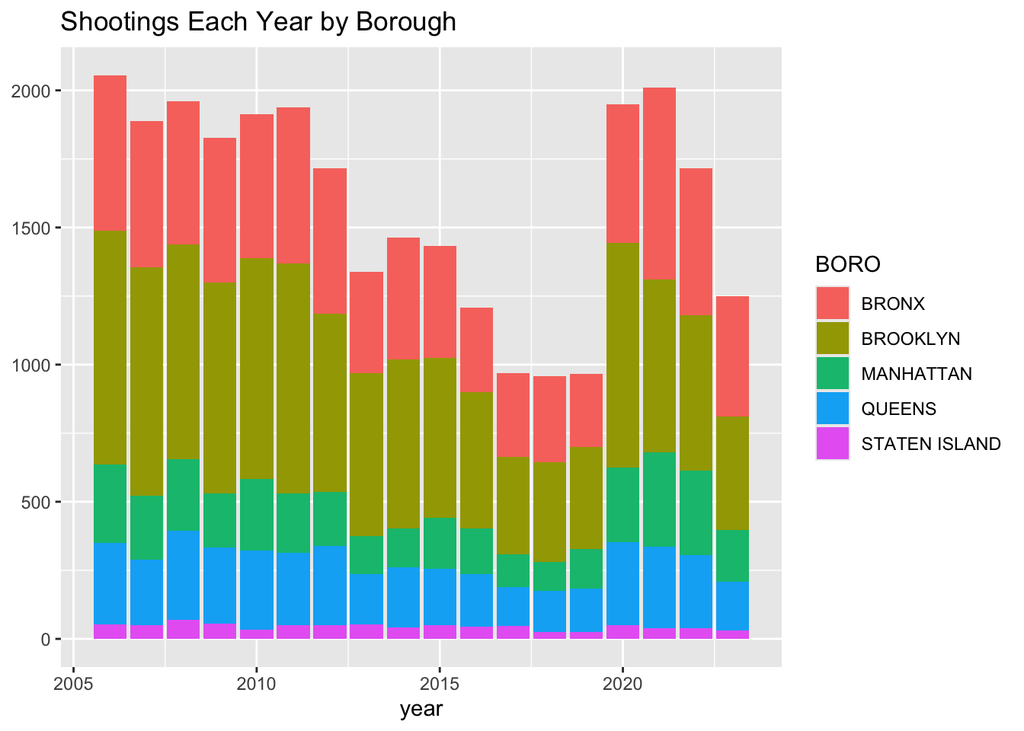

```r
nypd_by_date <- nypd %>%
  mutate(month = month(OCCUR_DATE),
         day = day(OCCUR_DATE),
         year = year(OCCUR_DATE),
         day_night = case_when(OCCUR_TIME > "21:00" | OCCUR_TIME < "07:00" ~ "night",
                               OCCUR_TIME <= "21:00" & OCCUR_TIME >= "07:00" ~ "day")) %>%
  group_by(day, month, year)

nypd_by_date %>%
  ggplot(aes(x=year, fill = BORO)) +
  geom_bar() +
  labs(title = "Shootings Each Year by Borough", y = NULL)
```

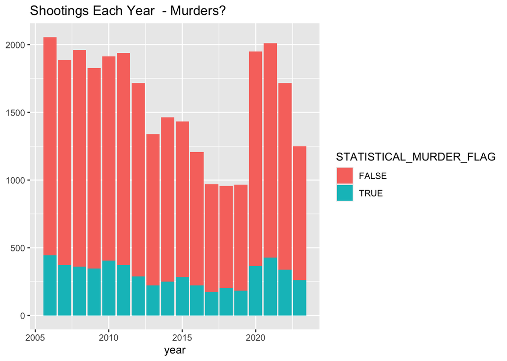

```r
nypd_by_date %>%
  ggplot(aes(x=year, fill = STATISTICAL_MURDER_FLAG)) +
  geom_bar() +
  labs(title = "Shootings Each Year  - Murders?", y = NULL)
```

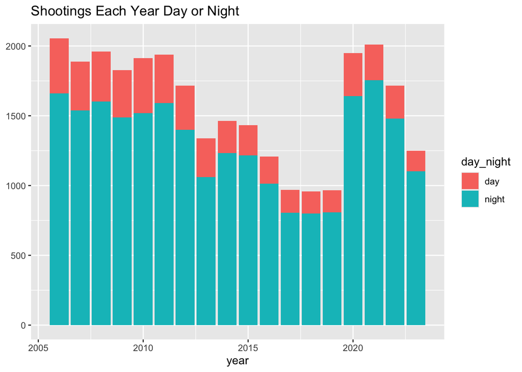

```r
nypd_by_date %>%
  ggplot(aes(x=year, fill = day_night)) +
  geom_bar() +
  labs(title = "Shootings Each Year Day or Night", y = NULL)
```

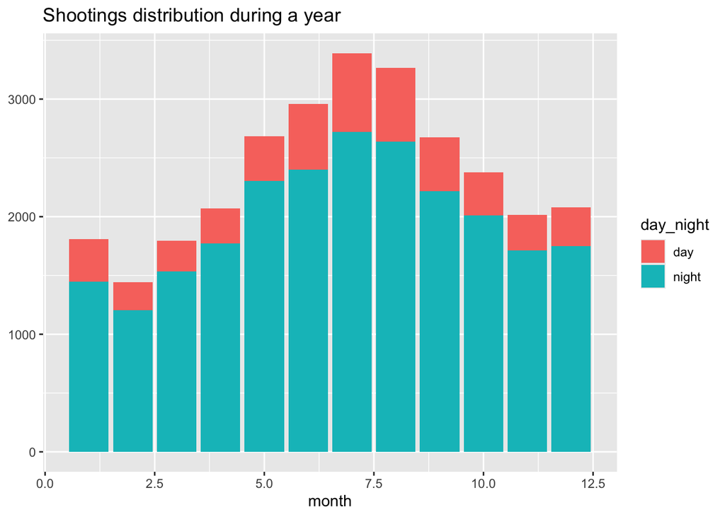

```r
nypd_by_date %>%
  ggplot(aes(x=month, fill = day_night)) +
  geom_bar() +
  labs(title = "Shootings distribution during a year", y = NULL)
```

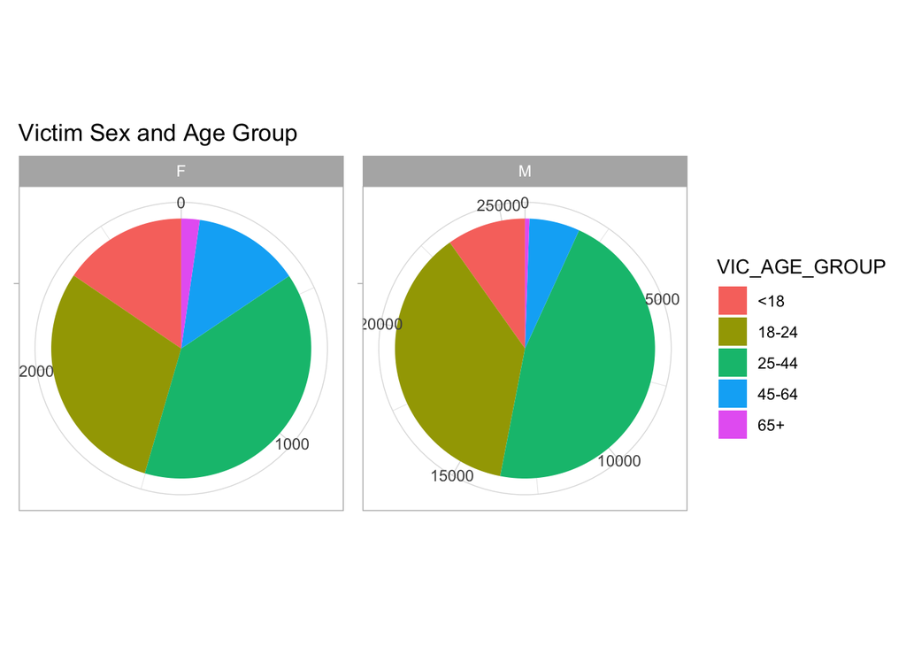

```r
nypd %>%
  filter(VIC_AGE_GROUP != "UNKNOWN" & VIC_AGE_GROUP != "1022") %>%
  filter(VIC_SEX != "U") %>%
  group_by(VIC_SEX, VIC_AGE_GROUP) %>%
  summarise(shootings = n()) %>%
  ggplot(aes(x="", y =shootings, fill = VIC_AGE_GROUP)) +
  geom_bar(stat = 'identity', width = 1) +
  coord_polar("y", start = 0 )+
  theme_light()+
  facet_wrap(~VIC_SEX, scales = "free") +
  labs(title = "Victim Sex and Age Group", x = NULL, y = NULL)
```

## Is there a noticeable change in shootings rate (per capita) for each borough?

Just to learn more about using geo plots, I wanted to use **plot_usmap** for this visualization. Slighly unsatisfactory as this function uses county names rather than borough names for labeling. (I’ms sure I could fix it if I spent more time). Also, as the changes over time are minor and the graphic is using colour to represent values, in hindsight, I could have made the conclusions more obvious. (In fact, my earlier graph in this report is probably a better way to show changes over time.). Nonetheless, this was useful learning.

To create the chart, I joined some basic population data (also from data.gov) with the nypd shootings data. As I only have population data for 2010, 2020, I decided to use these years to make a comparison to see changes over time.

The basic conclusion here is that comparing 2010 and 2020:

1. Bronx shows very little change and continues to have the highest shootings per capita rate
2. Brooklyn (Kings) has improved slightly, but is still second worst
3. Manhattan (New York) and Queens have improved somewhat
4. Staten Island (Richmond) has the lowest rate of shootings per capita

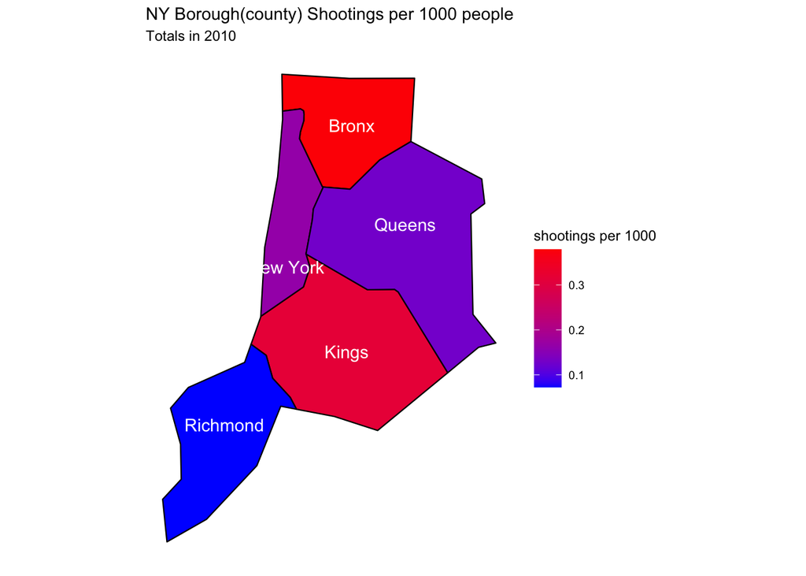

```r
plot_simple_map <- function(shootings_year) {

  pop_year <- pop %>%
    filter(year == shootings_year)

  nypd_map <- nypd %>%
    filter(year(OCCUR_DATE) == shootings_year) %>%
    group_by(fips) %>%
    summarise(shootings = n()) %>%
    full_join(pop_year, by = join_by(fips == fips)) %>%
    select(fips, shootings, population) %>%
    mutate(shootings_per_pop = shootings * 1000 / population)

  # Note: labels show counties which are equivalent to the boroughs even if names are different
  plot_usmap(data = nypd_map, regions = "counties", values = "shootings_per_pop",
             include = c(36005,36047,36061,36081,36085),
             labels = TRUE, label_color = "white") +
    scale_fill_continuous(low = "blue", high = "red", name = "shootings per 1000", label = scales::comma) +
    labs(title = "NY Borough(county) Shootings per 1000 people", subtitle = str_c("Totals in ", shootings_year)) +
    theme(legend.position = "right")
}
plot_simple_map(2010)
```

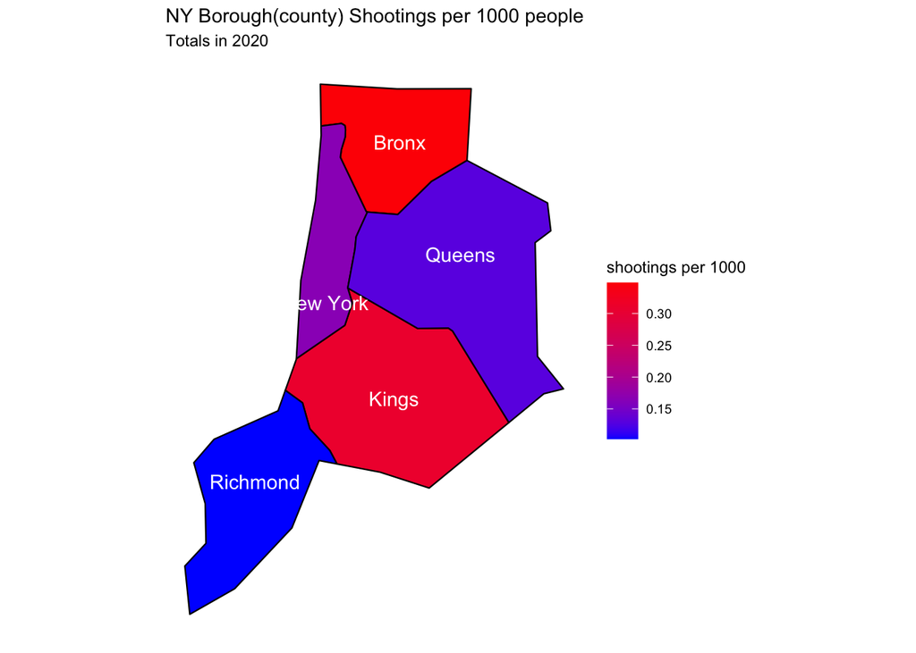

```r
plot_simple_map(2020)
```

## Is there a significant decrease in shootings over time?

A simple linear model to look at the trend in shootings over time.

```r
nypd_model <- nypd%>%
  mutate(month_year = floor_date(OCCUR_DATE, "month")) %>%
  group_by(month_year) %>%
  summarise(shootings = n())

simple_model <- lm(shootings ~ month_year, data = nypd_model)
summary(simple_model)
```

```
##
## Call:
## lm(formula = shootings ~ month_year, data = nypd_model)
##
## Residuals:
##    Min     1Q Median     3Q    Max
## -82.65 -37.56 -10.52  33.88 208.13
##
## Coefficients:
##               Estimate Std. Error t value Pr(>|t|)
## (Intercept) 256.900044  29.467128   8.718 7.91e-16 ***
## month_year   -0.007592   0.001783  -4.259 3.08e-05 ***
## ---
## Signif. codes:  0 '***' 0.001 '**' 0.01 '*' 0.05 '.' 0.1 ' ' 1
##
## Residual standard error: 49.72 on 214 degrees of freedom
## Multiple R-squared:  0.07814,    Adjusted R-squared:  0.07383
## F-statistic: 18.14 on 1 and 214 DF,  p-value: 3.076e-05
```

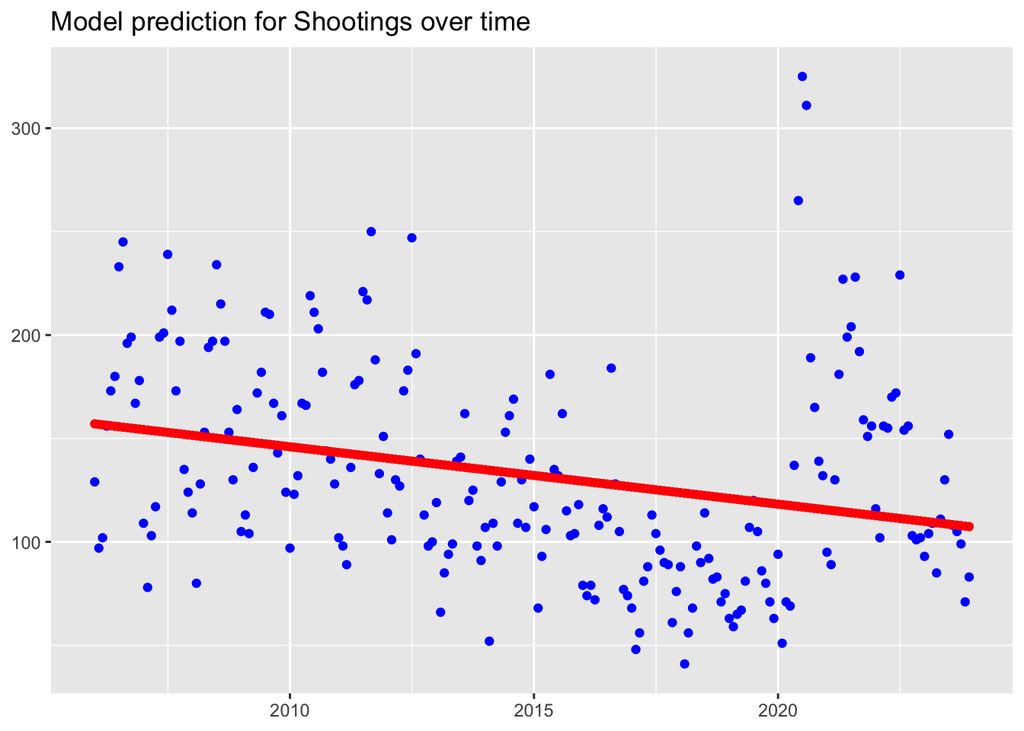

```r
nypd_model %>%
  mutate(predicted_shootings = predict(simple_model)) %>%
  ggplot() +
  geom_point(aes(x = month_year, y = shootings), colour = "blue") +
  geom_point(aes(x = month_year, y = predicted_shootings), colour = "red") +
  labs(title = "Model prediction for Shootings over time", x = NULL, y = NULL)
```

## Discussion about bias

The assessment question asks for a discussion on where bias might be introduced into the analysis.

*A list of possibilities:*

1. Handling of missing data. In particular only approx 50% of cases have perp race, sex, age information. Using the remaining data to conclude on distribution of these characteristics may be erroneous without understanding the reasons behind the missing values. Is it reasonable to assume they follow the same distribution as the known values or not?
2. It would seem important to understand more about the underlying populations before concluding on the meaningfulness of distribution of characteristics for perps and victims. If the underlying population is 90% white-hispanic vs 90% white vs 90% black, clearly that will determine the Baynesian probabilities of perps and victims coming from those racial classes. I avoided any analysis of race as I didn’t have this understanding when I compiled the document. Also, before concluding on the impact of racial characteristics, it would be important to look at other socio-economic factors such as income and housing. These may be the true causes of the observed differences.
3. Causation and correlation bias: the data show that you’re significantly more likely to be shot at night if you are a male under the age of 45. But is this just a reflection of who is on the streets? Similarly the data seem to show you are more likely to be shot during the summer months, but this may also just be that there are more people out and about during the warmer months.
4. Is the initial data collection biased? It is coming from the NYPD, does that source have an inherent bias in what is collected, reported, analysed and prosecuted. I don’t know, I would hope not at this base level, but it might be useful to have some alternative sources for comparison.

## Conclusions

There is an overall downward trend in the shootings in New York. Whilst the COVID period clearly had a negative impact (shootings almost doubled that year), the downward trend continued from that point. There are some simple conclusions that can be drawn such as; (a) shootings per capita is highest in Bronx and lowest in Staten Island, (b) more shootings happen at night and in the summer than during the day or the winter period. However, much of the interesting analysis regarding the impact of population demographics and other socio economic factors on shootings is prevented by the high number of missing values in the data and potential introduction of bias.